# Practical Machine Learning Project-HAR Data

Mohamed Rizwan

10/10/2019

##1. Description of HAR data

> HAR (human activity recognition) research has focused to predict “which” activity was performed at a specific point in time (like with the Daily Living Activities).

> Weight Lifting Exercises dataset investigated “how (well)” an activity was performed by the wearer.

> Six young health participants were asked to perform one set of 10 repetitions of the Unilateral Dumbbell Biceps Curl in five different fashions: - exactly according to the specification (Class A) # correct - throwing the elbows to the front (Class B) - lifting the dumbbell only halfway (Class C) - lowering the dumbbell only halfway (Class D) - throwing the hips to the front (Class E)

> Participants were supervised by an experienced weight lifter to make sure that all participants could easily simulate the mistakes

> Safe and controlled exercises by using a relatively light dumbbell (1.25kg).

*source: http://web.archive.org/web/20161224072740/http:/groupware.les.inf.puc-rio.br/har*

##2. Data Processing *Loaded required packages*

```r
library(dplyr)
```

```r
library(ggplot2)
library(caret)
library(rpart)
library(randomForest)
library(rattle)
```

### Data Clearning to prepare to get training set and testing sets

```r
training_data<-read.csv("https://d396qusza40orc.cloudfront.net/predmachlearn/pml-training.csv",
                        na.strings = c("NA","#DIV/0!",""),header=TRUE,sep = ",")
#Downloaded the training and test data from the given url, removed columns with blank cells and "#DIV/0!"

trfun <- function(x){sum(is.na(x))}
trainSet<- training_data[sapply(training_data,trfun)==0] # removed the columns with all NAs
trainSet <- trainSet[,-c(1:7)] # removed first 7 columns as they are not necessary for prediction
```

##3. Data Partitioned to create Training and Testing sets

```r
set.seed(1977)
Intrain <- createDataPartition(trainSet$classe,p=0.69,list = FALSE)
trainingOne <- trainSet[Intrain,]
testingOne <- trainSet[-Intrain,]
```

##4. Model Tuning with ML algos/methods #(i). method = Decision tree (Recurssive Partitioning and Regression Trees)

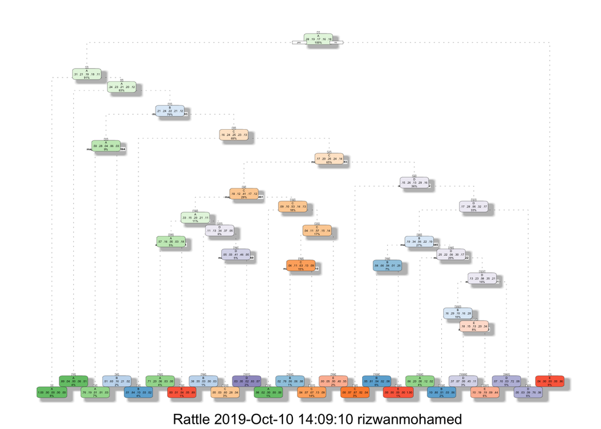

```r
set.seed(1977)
library(rattle)
library(rpart.plot)

modelTree<- rpart(trainingOne$classe ~ .,data=trainingOne,method ="class")
fancyRpartPlot(modelTree,cex=0.2)
```

```r
PredTree <- predict(modelTree,testingOne,type="class")
confusionMatrix(PredTree,testingOne$classe)
```

```
## Confusion Matrix and Statistics
##
##           Reference
## Prediction    A    B    C    D    E
##          A 1421  207   20   51   12
##          B   85  763   71   59   46
##          C   67   75  848  206   95
##          D   97   72   47  602   69
##          E   59   60   74   78  896
##
## Overall Statistics
##
##                Accuracy : 0.7451
##                  95% CI : (0.7339, 0.756)
##     No Information Rate : 0.2844
##     P-Value [Acc > NIR] : < 2.2e-16
##
##                   Kappa : 0.6778
##
##  Mcnemar's Test P-Value : < 2.2e-16
##
## Statistics by Class:
##
##                      Class: A Class: B Class: C Class: D Class: E
## Sensitivity            0.8219   0.6483   0.8000  0.60442   0.8014
## Specificity            0.9333   0.9468   0.9118  0.94394   0.9454
## Pos Pred Value         0.8305   0.7451   0.6569  0.67869   0.7678
## Neg Pred Value         0.9295   0.9181   0.9557  0.92413   0.9548
## Prevalence             0.2844   0.1936   0.1743  0.16382   0.1839
## Detection Rate         0.2337   0.1255   0.1395  0.09901   0.1474
## Detection Prevalence   0.2814   0.1684   0.2123  0.14589   0.1919
## Balanced Accuracy      0.8776   0.7975   0.8559  0.77418   0.8734
```

*Accuracy_of* model_ = 74.51%

###(ii). method = Random Forest

```r
set.seed(1980)
library(randomForest)
modelRF<- randomForest(trainingOne$classe ~ .,data=trainingOne)
modelRF$finalModel$forest
```

```r
PredRF <- predict(modelRF,testingOne)
confRF <- confusionMatrix(PredRF,testingOne$classe)
confRF
```

```
## Confusion Matrix and Statistics
##
##           Reference
## Prediction    A    B    C    D    E
##          A 1726    2    0    0    0
##          B    2 1171    8    0    0
##          C    0    4 1050   17    1
##          D    0    0    2  979    3
##          E    1    0    0    0 1114
##
## Overall Statistics
##
##                Accuracy : 0.9934
##                  95% CI : (0.9911, 0.9953)
##     No Information Rate : 0.2844
##     P-Value [Acc > NIR] : < 2.2e-16
##
##                   Kappa : 0.9917
##
##  Mcnemar's Test P-Value : NA
##
## Statistics by Class:
##
##                      Class: A Class: B Class: C Class: D Class: E
## Sensitivity            0.9983   0.9949   0.9906   0.9829   0.9964
## Specificity            0.9995   0.9980   0.9956   0.9990   0.9998
## Pos Pred Value         0.9988   0.9915   0.9795   0.9949   0.9991
## Neg Pred Value         0.9993   0.9988   0.9980   0.9967   0.9992
## Prevalence             0.2844   0.1936   0.1743   0.1638   0.1839
## Detection Rate         0.2839   0.1926   0.1727   0.1610   0.1832
## Detection Prevalence   0.2842   0.1942   0.1763   0.1618   0.1834
## Balanced Accuracy      0.9989   0.9964   0.9931   0.9910   0.9981
```

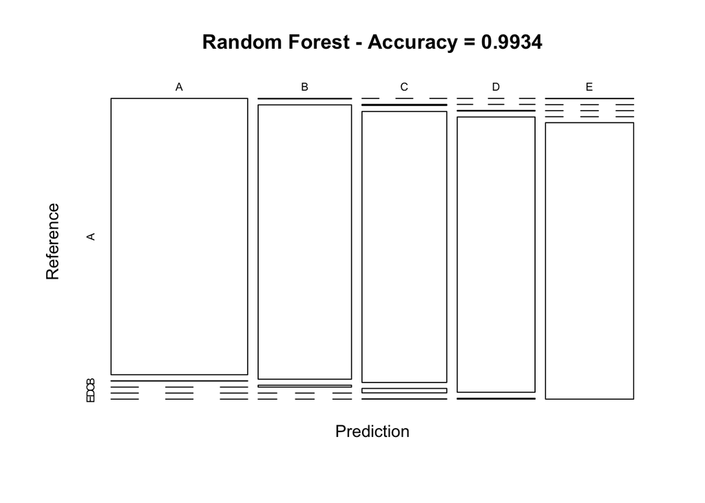

```r
plot(confRF$table, col = confRF$byClass,main = paste("Random Forest - Accuracy =",
                  round(confRF$overall['Accuracy'], 4)))
```

###(iii). method = Support Vector Machine

```r
set.seed(1990)
library(kernlab)
modelSVM <- ksvm(trainingOne$classe ~ ., data = trainingOne, type= "nu-svc",nu=0.1)
PredSVM <- predict(modelSVM,testingOne,type="response")
confusionMatrix(PredSVM,testingOne$classe)
```

```
## Confusion Matrix and Statistics
##
##           Reference
## Prediction    A    B    C    D    E
##          A 1723   43    0    2    0
##          B    5 1122    6    0    1
##          C    0    6 1045   48    3
##          D    0    0    6  946   13
##          E    1    6    3    0 1101
##
## Overall Statistics
##
##                Accuracy : 0.9765
##                  95% CI : (0.9724, 0.9801)
##     No Information Rate : 0.2844
##     P-Value [Acc > NIR] : < 2.2e-16
##
##                   Kappa : 0.9702
##
##  Mcnemar's Test P-Value : NA
##
## Statistics by Class:
##
##                      Class: A Class: B Class: C Class: D Class: E
## Sensitivity            0.9965   0.9533   0.9858   0.9498   0.9848
## Specificity            0.9897   0.9976   0.9886   0.9963   0.9980
## Pos Pred Value         0.9745   0.9894   0.9483   0.9803   0.9910
## Neg Pred Value         0.9986   0.9889   0.9970   0.9902   0.9966
## Prevalence             0.2844   0.1936   0.1743   0.1638   0.1839
## Detection Rate         0.2834   0.1845   0.1719   0.1556   0.1811
## Detection Prevalence   0.2908   0.1865   0.1812   0.1587   0.1827
## Balanced Accuracy      0.9931   0.9754   0.9872   0.9730   0.9914
```

Accuracy of the model =97.65%

##5. Selecting the appropriate model to find the answers to the test data for the quiz

```r
test_data <- read.csv("https://d396qusza40orc.cloudfront.net/predmachlearn/pml-testing.csv",
                        na.strings = c("NA","#DIV/0!",""),header=TRUE, sep=",")

predict_Quiz <- predict(modelRF, newdata=test_data)
predict_Quiz
```

```
##  1  2  3  4  5  6  7  8  9 10 11 12 13 14 15 16 17 18 19 20
##  B  A  B  A  A  E  D  B  A  A  B  C  B  A  E  E  A  B  B  B
## Levels: A B C D E
```